# ANALISIS DE SENTIMIENTO

### Configuración Inicial y Librerías

```python
#  IMPORTACIÓN DE LIBRERÍAS
import pandas as pd
import numpy as np
import re
import json
import warnings
from datetime import datetime
from collections import Counter

# Visualización
import matplotlib.pyplot as plt
import seaborn as sns
try:
    from wordcloud import WordCloud
    WORDCLOUD_AVAILABLE = True
except ImportError:
    WORDCLOUD_AVAILABLE = False

# Métricas y Machine Learning
import sklearn
from sklearn.metrics import (
    accuracy_score, precision_score, recall_score, f1_score,
    confusion_matrix, classification_report, cohen_kappa_score
)
from sklearn.model_selection import train_test_split

# Procesamiento de Lenguaje Natural (NLP)
import nltk
import spacy
from textblob import TextBlob
from nltk.sentiment import SentimentIntensityAnalyzer

# Modelos Avanzados (Transformers)
import torch
from transformers import pipeline, AutoTokenizer, AutoModelForSequenceClassification

#  CONFIGURACIÓN DEL ENTORNO
warnings.filterwarnings('ignore')
plt.style.use('seaborn-v0_8-darkgrid')
sns.set_palette("husl")

# Recursos NLTK
nltk.download('vader_lexicon', quiet=True)
nltk.download('punkt', quiet=True)
nltk.download('stopwords', quiet=True)

# Información del sistema
print("\n✅ Entorno unificado correctamente")
print("-" * 30)
print(f"🔧 Versiones:")
print(f"  - Pandas: {pd.__version__}")
print(f"  - Scikit-learn: {sklearn.__version__}")
print(f"  - PyTorch: {torch.__version__}")
print(f"  - Dispositivo: {'🚀 CUDA (GPU)' if torch.cuda.is_available() else '💻 CPU'}")
```

```
✅ Entorno unificado correctamente
------------------------------
🔧 Versiones:
  - Pandas: 2.2.2
  - Scikit-learn: 1.6.1
  - PyTorch: 2.9.0+cu126
  - Dispositivo: 🚀 CUDA (GPU)
```

## Carga y Limpieza de Datos

```python
# Cargar dataset
df = pd.read_csv('Reviews_EN.csv')
print(f" Dataset cargado: {len(df)} reseñas totales")
print(f" Columnas disponibles: {df.columns.tolist()}")

# Ver primeras filas
df.head()
```

```
 Dataset cargado: 2510 reseñas totales
 Columnas disponibles: ['createTime', 'starRating', 'comment', 'review_clean']
```

|  | createTime | starRating | comment | review_clean |
| --- | --- | --- | --- | --- |
| 0 | 2018-02-24T16:23:44.530Z | FIVE | (Translated by Google) Very welcoming place wi... | (Translated by Google) Very welcoming place wi... |
| 1 | 2019-09-29T18:47:10.530323Z | FIVE | (Translated by Google) We stopped by for coffe... | (Translated by Google) We stopped by for coffe... |
| 2 | 2019-09-24T19:01:11.659349Z | FOUR | NaN | NaN |
| 3 | 2019-09-23T17:26:48.376177Z | FOUR | Good coffee and cake, but heavy traffic an arm... | Good coffee and cake, but heavy traffic an arm... |
| 4 | 2019-09-15T15:50:20.745042Z | FOUR | (Translated by Google) Good place for breakfas... | (Translated by Google) Good place for breakfas... |

```python
# LIMPIEZA DE DATOS MEJORADA
def clean_and_extract_text(comment):
    if pd.isna(comment):
        return ""

    text = str(comment)

    # 1. Estrategia robusta para traducciones de Google
    # Primero cortamos todo lo que venga después de "(Original)" si existe
    if "(Original)" in text:
        text = text.split("(Original)")[0]

    # Luego eliminamos la etiqueta de inicio simplemente reemplazándola
    text = text.replace("(Translated by Google)", "")

    # 2. Limpieza de ruido en el texto
    text = re.sub(r'http\S+|www\S+|https\S+', '', text)  # Eliminar URLs
    text = re.sub(r'<.*?>', '', text)                    # Eliminar etiquetas HTML
    text = re.sub(r'\s+', ' ', text)                     # Normalizar espacios múltiples

    return text.strip()

# Aplicar limpieza y extracción
df['review_text'] = df['comment'].apply(clean_and_extract_text)

# Crear versión en minúsculas
df['review_clean'] = df['review_text'].str.lower()

# Filtrar reseñas vacías
df = df[df['review_text'].str.len() > 0]

print(f"✅ Limpieza completada y corregida: {len(df)} reseñas válidas.")
```

```
✅ Limpieza completada y corregida: 1633 reseñas válidas.
```

```python
# MÉTRICAS TEXTUALES BÁSICAS

# Calculate word count
df['word_count'] = df['review_text'].str.split().str.len()

# Estadísticas descriptivas
print("ESTADÍSTICAS DEL DATASET")
print("="*50)
print(f"Total de reseñas: {len(df)}")
print(f"Palabras por reseña:")
print(f"  - Promedio: {df['word_count'].mean():.1f}")
print(f"  - Mediana: {df['word_count'].median():.0f}")
print(f"  - Mínimo: {df['word_count'].min()}")
print(f"  - Máximo: {df['word_count'].max()}")
print(f"  - Desviación estándar: {df['word_count'].std():.1f}")

# Distribución de calificaciones
if 'starRating' in df.columns:
    print("\n⭐ DISTRIBUCIÓN DE CALIFICACIONES")
    print("="*50)
    rating_map = {'ONE': 1, 'TWO': 2, 'THREE': 3, 'FOUR': 4, 'FIVE': 5}
    # FIX: Map starRating to numerical values, then sort numerically in descending order
    rating_counts_sorted_numerical = df['starRating'].map(rating_map).value_counts().sort_index(ascending=False)

    for stars_num, count in rating_counts_sorted_numerical.items():
        stars = "⭐" * stars_num
        percentage = (count / len(df)) * 100
        bar = "█" * int(percentage / 2)
        print(f"{stars_num} {stars:5} {bar:35} {count:4} ({percentage:.1f}%)")

    # Mapear calificaciones a sentimiento esperado
    df['expected_sentiment'] = df['starRating'].map({
        'ONE': 'negative', 'TWO': 'negative',
        'THREE': 'neutral',
        'FOUR': 'positive', 'FIVE': 'positive'
    })

# Análisis de Frecuencia de Palabras (Top 15)
print("\n TÉRMINOS MÁS FRECUENTES EN LAS RESEÑAS")
print("-" * 50)
# Definir stop_words básicas para limpiar el análisis de frecuencia
stop_words_basic = {'the', 'and', 'is', 'it', 'to', 'a', 'of', 'in', 'for', 'with','that',"it’s","it's", "its",'have','this',
                    'was', 'on', 'at', 'very', 'but', 'so', 'we', 'they', 'i', 'my','are','you','were','not','from'}

all_words = ' '.join(df['review_clean'].tolist()).split()
filtered_words = [word for word in all_words if word not in stop_words_basic and len(word) > 2]
word_freq = Counter(filtered_words).most_common(15)

for word, count in word_freq:
    print(f" • {word:12}: {count} menciones")
```

```
ESTADÍSTICAS DEL DATASET
==================================================
Total de reseñas: 1633
Palabras por reseña:
  - Promedio: 22.9
  - Mediana: 16
  - Mínimo: 1
  - Máximo: 205
  - Desviación estándar: 24.1

⭐ DISTRIBUCIÓN DE CALIFICACIONES
==================================================
5 ⭐⭐⭐⭐⭐ █████████████████████████████████   1092 (66.9%)
4 ⭐⭐⭐⭐  ████████                             268 (16.4%)
3 ⭐⭐⭐   ███                                  123 (7.5%)
2 ⭐⭐    █                                     56 (3.4%)
1 ⭐     ██                                    94 (5.8%)

 TÉRMINOS MÁS FRECUENTES EN LAS RESEÑAS
--------------------------------------------------
 • good        : 508 menciones
 • coffee      : 437 menciones
 • place       : 410 menciones
 • service     : 293 menciones
 • great       : 243 menciones
 • delicious   : 192 menciones
 • excellent   : 184 menciones
 • nice        : 184 menciones
 • friendly    : 175 menciones
 • breakfast   : 165 menciones
 • staff       : 152 menciones
 • food        : 147 menciones
 • service.    : 107 menciones
 • everything  : 102 menciones
 • super       : 96 menciones
```

[figure not shown]

```python
# Visualizaciones
fig, axes = plt.subplots(2, 2, figsize=(15, 10))

# Histograma de longitud de reseñas
axes[0, 0].hist(df['word_count'], bins=30, edgecolor='black', alpha=0.7, color='skyblue')
axes[0, 0].set_xlabel('Número de Palabras')
axes[0, 0].set_ylabel('Frecuencia')
axes[0, 0].set_title('Distribución de Palabras por Reseña')
axes[0, 0].grid(True, alpha=0.3)

# Distribución de calificaciones
if 'starRating' in df.columns:
    rating_counts = df['starRating'].value_counts().sort_index()
    axes[0, 1].bar(range(len(rating_counts)), rating_counts.values,
                  color=['red', 'orange', 'yellow', 'lightgreen', 'green'])
    axes[0, 1].set_xticks(range(len(rating_counts)))
    axes[0, 1].set_xticklabels(['1⭐', '2⭐', '3⭐', '4⭐', '5⭐'])
axes[0, 1].set_ylabel('Número de Reseñas')
axes[0, 1].set_title('Distribución de Calificaciones')
axes[0, 1].grid(True, alpha=0.3)

# Box plot de palabras por calificación
if 'starRating' in df.columns:
    data_for_box = [df[df['starRating'] == rating]['word_count'].values
                   for rating in ['ONE', 'TWO', 'THREE', 'FOUR', 'FIVE']]
    axes[1, 0].boxplot(data_for_box, labels=['1⭐', '2⭐', '3⭐', '4⭐', '5⭐'])
    axes[1, 0].set_xlabel('Calificación')
    axes[1, 0].set_ylabel('Número de Palabras')
    axes[1, 0].set_title('Longitud de Reseña por Calificación')
    axes[1, 0].grid(True, alpha=0.3)

# Evolución temporal
if 'createTime' in df.columns:
    df['date'] = pd.to_datetime(df['createTime'], format='ISO8601')
    df['year_month'] = df['date'].dt.to_period('M')
    time_counts = df.groupby('year_month').size()
    axes[1, 1].plot(time_counts.index.to_timestamp(), time_counts.values,
                   marker='o', linewidth=2, color='purple')
    axes[1, 1].set_xlabel('Fecha')
    axes[1, 1].set_ylabel('Número de Reseñas')
    axes[1, 1].set_title('Evolución Temporal de Reseñas')
    axes[1, 1].grid(True, alpha=0.3)
    axes[1, 1].tick_params(axis='x', rotation=45)

plt.tight_layout()
plt.show()
```

1. La gran mayoría de las barras están concentradas a la izquierda. Esto indica que la mayoría de los comentarios son cortos (probablemente entre 10 y 50 palabras). Hay una "cola larga" hacia la derecha, lo que significa que existen muy pocos comentarios extremadamente largos.
2. Una barra dominante (probablemente la de 5 estrellas) que es mucho más alta que las demás, seguida quizás por la de 4 estrellas. Las barras de 1, 2 y 3 estrellas son mucho más bajas.
3. El diagrama de caja revela una correlación inversa interesante entre la satisfacción del cliente y la longitud de la reseña. Se observa que las calificaciones más bajas (1 y 2 estrellas) presentan una mediana de palabras superior y una mayor dispersión (cajas más grandes) en comparación con las calificaciones altas (5 estrellas) Este comportamiento indica que los usuarios insatisfechos tienden a detallar exhaustivamente sus experiencias negativas para justificar su queja, mientras que los clientes satisfechos suelen ser más concisos y directos (ej. "Excelente servicio").
4. Una línea que muestra cuántas reseñas se recibieron a lo largo del tiempo. Es probable que veas una tendencia ascendente (el lugar se hizo más popular) o picos específicos en ciertas fechas.

En resumen, el análisis gráfico revela un dataset de cafetería mayoritariamente positivo pero altamente desbalanceado, con reseñas breves y un vocabulario dominado por la satisfacción del cliente ('good', 'great'). Esto sugiere que el desafío principal del modelo será detectar correctamente las pocas reseñas negativas sin dejarse llevar por la tendencia positiva general

## Análisis de Aspectos del Negocio

```python
# Definir aspectos del negocio y sus palabras clave
business_aspects = {
    'Coffee': {
        'keywords': ['coffee', 'espresso', 'cappuccino', 'latte', 'americano', 'brew', 'beans', 'cafe'],
        'positive': ['good coffee', 'great coffee', 'excellent coffee', 'best coffee',
                    'delicious coffee', 'amazing coffee', 'perfect coffee'],
        'negative': ['bad coffee', 'terrible coffee', 'cold coffee', 'burnt coffee',
                    'weak coffee', 'bitter coffee', 'awful coffee']
    },
    'Service': {
        'keywords': ['service', 'staff', 'waiter', 'waitress', 'server', 'employee',
                    'attention', 'attendant'],
        'positive': ['friendly staff', 'great service', 'excellent service', 'helpful',
                    'attentive', 'professional', 'kind staff'],
        'negative': ['rude staff', 'poor service', 'slow service', 'unfriendly',
                    'unprofessional', 'terrible service', 'bad service']
    },
    'Food': {
        'keywords': ['food', 'sandwich', 'pastry', 'cake', 'breakfast', 'lunch', 'meal',
                    'snack', 'croissant', 'toast', 'eggs'],
        'positive': ['delicious food', 'fresh food', 'tasty', 'great food', 'yummy',
                    'amazing food', 'excellent food'],
        'negative': ['bad food', 'stale', 'cold food', 'tasteless', 'bland',
                    'terrible food', 'disgusting food']
    },
    'Ambience': {
        'keywords': ['atmosphere', 'ambience', 'place', 'environment', 'decor', 'music',
                    'vibe', 'interior', 'setting'],
        'positive': ['cozy', 'comfortable', 'nice atmosphere', 'beautiful', 'relaxing',
                    'lovely place', 'great atmosphere'],
        'negative': ['noisy', 'dirty', 'uncomfortable', 'crowded', 'unpleasant',
                    'terrible atmosphere', 'bad vibe']
    },
    'Price': {
        'keywords': ['price', 'cost', 'expensive', 'cheap', 'affordable', 'value',
                    'money', 'worth', '€', '$'],
        'positive': ['good value', 'reasonable price', 'affordable', 'worth it',
                    'fair price', 'great value', 'good price'],
        'negative': ['overpriced', 'expensive', 'too expensive', 'not worth',
                    'rip off', 'costly', 'high price']
    },
    'Location': {
        'keywords': ['location', 'place', 'spot', 'area', 'neighborhood', 'street',
                    'parking', 'access'],
        'positive': ['great location', 'convenient', 'easy to find', 'good location',
                    'perfect location', 'accessible'],
        'negative': ['bad location', 'hard to find', 'difficult parking', 'terrible location',
                    'inconvenient', 'far']
    }
}

print(f" Analizando {len(business_aspects)} aspectos del negocio...")
```

```
 Analizando 6 aspectos del negocio...
```

```python
aspect_analysis = {}

for aspect, data in business_aspects.items():
    mentions = 0
    positive_mentions = 0
    negative_mentions = 0
    neutral_mentions = 0

    for idx, row in df.iterrows():
        text_lower = str(row['review_clean']) if pd.notna(row['review_clean']) else ""

        # Verificar si el aspecto es mencionado
        if any(keyword in text_lower for keyword in data['keywords']):
            mentions += 1

            # Verificar sentimiento específico del aspecto
            has_positive = any(pos_phrase in text_lower for pos_phrase in data['positive'])
            has_negative = any(neg_phrase in text_lower for neg_phrase in data['negative'])

            if has_positive and not has_negative:
                positive_mentions += 1
            elif has_negative and not has_positive:
                negative_mentions += 1
            else:
                # Si no hay indicadores específicos, usar sentimiento general
                if row['expected_sentiment'] == 'positive':
                    positive_mentions += 0.5  # Peso reducido
                elif row['expected_sentiment'] == 'negative':
                    negative_mentions += 0.5
                else:
                    neutral_mentions += 1

    if mentions > 0:
        aspect_analysis[aspect] = {
            'total_mentions': mentions,
            'mention_rate': (mentions / len(df)) * 100,
            'positive_count': positive_mentions,
            'negative_count': negative_mentions,
            'neutral_count': neutral_mentions,
            'positive_rate': (positive_mentions / mentions) * 100 if mentions > 0 else 0,
            'negative_rate': (negative_mentions / mentions) * 100 if mentions > 0 else 0,
            'net_sentiment': ((positive_mentions - negative_mentions) / mentions) * 100 if mentions > 0 else 0
        }

# Ordenar por sentimiento neto
sorted_aspects = sorted(aspect_analysis.items(), key=lambda x: x[1]['net_sentiment'], reverse=True)

print("\n ANÁLISIS DE ASPECTOS DEL NEGOCIO")
print("="*80)
print("(Ordenados por sentimiento neto)\n")
print(f"{'Aspecto':15} {'Menciones':>10} {'Tasa':>8} {'Positivo':>10} {'Negativo':>10} {'Neto':>10}")
print("-"*75)

for aspect, data in sorted_aspects:
    print(f"{aspect:15} {data['total_mentions']:>10} {data['mention_rate']:>7.1f}% "
          f"{data['positive_rate']:>9.1f}% {data['negative_rate']:>9.1f}% "
          f"{data['net_sentiment']:>+9.1f}%")
```

```
 ANÁLISIS DE ASPECTOS DEL NEGOCIO
================================================================================
(Ordenados por sentimiento neto)

Aspecto          Menciones     Tasa   Positivo   Negativo       Neto
---------------------------------------------------------------------------
Service                786    48.1%      60.2%       4.5%     +55.7%
Coffee                 732    44.8%      57.0%       4.0%     +53.0%
Ambience               667    40.8%      54.9%       3.0%     +51.9%
Food                   737    45.1%      48.2%       3.3%     +45.0%
Location               644    39.4%      45.1%       4.3%     +40.8%
Price                  276    16.9%      36.6%      34.1%      +2.5%
```

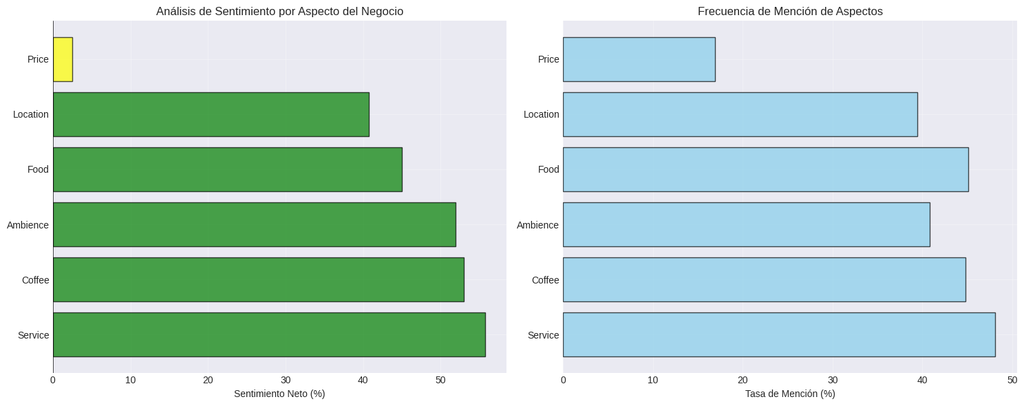

```python
# Visualización de aspectos
PLOTS_AVAILABLE = True # Define PLOTS_AVAILABLE para resolver NameError
if PLOTS_AVAILABLE and aspect_analysis:
    fig, (ax1, ax2) = plt.subplots(1, 2, figsize=(15, 6))

    # Gráfico de barras del sentimiento neto
    aspects_list = [a[0] for a in sorted_aspects]
    net_scores = [a[1]['net_sentiment'] for a in sorted_aspects]
    colors = ['green' if s > 20 else 'red' if s < -20 else 'yellow' for s in net_scores]

    ax1.barh(aspects_list, net_scores, color=colors, alpha=0.7, edgecolor='black')
    ax1.set_xlabel('Sentimiento Neto (%)')
    ax1.set_title('Análisis de Sentimiento por Aspecto del Negocio')
    ax1.axvline(x=0, color='black', linewidth=0.5)
    ax1.grid(True, alpha=0.3)

    # Gráfico de menciones
    mention_rates = [a[1]['mention_rate'] for a in sorted_aspects]
    ax2.barh(aspects_list, mention_rates, color='skyblue', alpha=0.7, edgecolor='black')
    ax2.set_xlabel('Tasa de Mención (%)')
    ax2.set_title('Frecuencia de Mención de Aspectos')
    ax2.grid(True, alpha=0.3)

    plt.tight_layout()
    plt.show()
else:
    if not PLOTS_AVAILABLE:
        print("\n Gráficos no disponibles - instale matplotlib para visualizaciones")
```

## WordClouds por Sentimiento

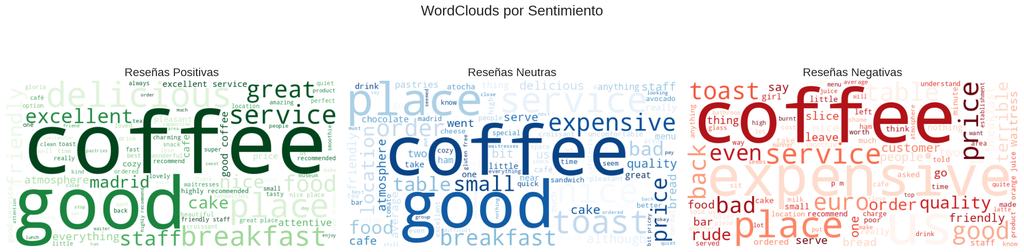

```python
# Generar WordClouds si la librería está disponible
if WORDCLOUD_AVAILABLE and PLOTS_AVAILABLE:
    from wordcloud import WordCloud

    fig, axes = plt.subplots(1, 3, figsize=(20, 6))

    # WordCloud para reseñas positivas
    positive_text = ' '.join(df[df['expected_sentiment'] == 'positive']['review_clean'].tolist())
    if positive_text:
        wc_positive = WordCloud(width=800, height=400, background_color='white',
                                colormap='Greens', max_words=100).generate(positive_text)
        axes[0].imshow(wc_positive, interpolation='bilinear')
        axes[0].set_title('Reseñas Positivas', fontsize=16)
        axes[0].axis('off')

    # WordCloud para reseñas neutrales
    neutral_text = ' '.join(df[df['expected_sentiment'] == 'neutral']['review_clean'].tolist())
    if neutral_text:
        wc_neutral = WordCloud(width=800, height=400, background_color='white',
                               colormap='Blues', max_words=100).generate(neutral_text)
        axes[1].imshow(wc_neutral, interpolation='bilinear')
        axes[1].set_title('Reseñas Neutras', fontsize=16)
        axes[1].axis('off')

    # WordCloud para reseñas negativas
    negative_text = ' '.join(df[df['expected_sentiment'] == 'negative']['review_clean'].tolist())
    if negative_text:
        wc_negative = WordCloud(width=800, height=400, background_color='white',
                                colormap='Reds', max_words=100).generate(negative_text)
        axes[2].imshow(wc_negative, interpolation='bilinear')
        axes[2].set_title('Reseñas Negativas', fontsize=16)
        axes[2].axis('off')

    plt.suptitle('WordClouds por Sentimiento', fontsize=20)
    plt.tight_layout()
    plt.show()
else:
    print(" WordCloud no disponible - instale 'wordcloud' para generar nubes de palabras")
```

## Análisis con Modelos Avanzados

### Modelo 1: Análisis por Palabras Clave (Baseline)(Método de Palabras Clave)

En esta etapa, se implementó un método de análisis de sentimiento basado en listas de palabras. El sistema utiliza dos listas predefinidas: una con palabras de significado claramente positivo (como 'excelente' o 'increíble') y otra con palabras claramente negativas (como 'terrible' o 'grosero').

```python
# Diccionarios ampliados de palabras positivas y negativas
positive_words = set([
    'excellent', 'amazing', 'wonderful', 'fantastic', 'great', 'good', 'love', 'loved',
    'perfect', 'best', 'awesome', 'delicious', 'friendly', 'nice', 'recommend',
    'beautiful', 'clean', 'fresh', 'quality', 'tasty', 'cozy', 'comfortable',
    'spectacular', 'charming', 'lovely', 'pleasant', 'enjoyable', 'exceptional',
    'outstanding', 'superb', 'brilliant', 'fabulous', 'terrific', 'marvelous',
    'excellent', 'extraordinary', 'phenomenal', 'remarkable', 'splendid', 'magnificent'
])

negative_words = set([
    'bad', 'terrible', 'horrible', 'awful', 'worst', 'poor', 'disappointing',
    'rude', 'slow', 'cold', 'dirty', 'expensive', 'overpriced', 'never', 'avoid',
    'disgusting', 'unpleasant', 'mediocre', 'waste', 'noisy', 'uncomfortable',
    'disappointed', 'unfriendly', 'unprofessional', 'unhappy', 'dissatisfied',
    'pathetic', 'gross', 'nasty', 'dreadful', 'lousy', 'inferior', 'unacceptable',
    'appalling', 'atrocious', 'abysmal', 'horrendous', 'inadequate', 'substandard'
])

def keyword_sentiment_analysis(text):
    """Análisis de sentimiento basado en palabras clave"""
    text_lower = str(text).lower()
    words = text_lower.split()

    pos_count = sum(1 for word in words if word in positive_words)
    neg_count = sum(1 for word in words if word in negative_words)

    # Intensificadores
    if 'very' in words or 'really' in words or 'extremely' in words:
        pos_count *= 1.5
        neg_count *= 1.5

    # Negación
    if 'not' in words or "n't" in text_lower:
        pos_count, neg_count = neg_count * 0.5, pos_count * 0.5

    # Clasificación
    total_sentiment = pos_count - neg_count

    if total_sentiment > 1:
        return 'positive'
    elif total_sentiment < -1:
        return 'negative'
    else:
        return 'neutral'

# Aplicar análisis
df['keyword_sentiment'] = df['review_text'].apply(keyword_sentiment_analysis)

print(" Análisis por palabras clave completado")
```

```
 Análisis por palabras clave completado
```

```python
#VISUALIZACION
print("\n RESULTADOS DEL MODELO (Keyword Sentiment)")
print("="*60)

# 1. Verificamos cantidad de reseñas procesadas
total_classified = df['keyword_sentiment'].notna().sum()
print(f"Reseñas procesadas: {total_classified}/{len(df)}\n")

# 2. Distribución de Sentimientos (Gráfico ASCII)
sentiment_dist = df['keyword_sentiment'].value_counts()
print("DISTRIBUCIÓN DE PREDICCIONES:")
print("-" * 40)
for sentiment, count in sentiment_dist.items():
    percentage = (count / len(df)) * 100
    bar = "█" * int(percentage / 2)  # Cada bloque es 2%
    print(f"{sentiment:10} {bar:30} {count:4} ({percentage:.1f}%)")

# 3. Métricas de Negocio
positive_pct = (df['keyword_sentiment'] == 'positive').mean() * 100
negative_pct = (df['keyword_sentiment'] == 'negative').mean() * 100
neutral_pct = (df['keyword_sentiment'] == 'neutral').mean() * 100

print("\n MÉTRICAS CLAVE:")
print("-" * 40)
print(f"Puntuación Neta (Pos - Neg): {(positive_pct - negative_pct):.1f}")
print(f"Índice de Satisfacción:      {positive_pct:.1f}%")
print(f"Tasa de Insatisfacción:      {negative_pct:.1f}%")
```

```
 RESULTADOS DEL MODELO (Keyword Sentiment)
============================================================
Reseñas procesadas: 1633/1633

DISTRIBUCIÓN DE PREDICCIONES:
----------------------------------------
neutral    ████████████████████████        799 (48.9%)
positive   ███████████████████████         768 (47.0%)
negative   ██                               66 (4.0%)

 MÉTRICAS CLAVE:
----------------------------------------
Puntuación Neta (Pos - Neg): 43.0
Índice de Satisfacción:      47.0%
Tasa de Insatisfacción:      4.0%
```

```
 VALIDACIÓN
============================================================
Exactitud (Accuracy): 52.60% (859/1633 aciertos)

MATRIZ DE CONFUSIÓN (Real vs Predicho):
---------------------------------------------
                           PREDICHO
REAL       | Positive Neutral  Negative
---------------------------------------------
positive   |   745      572       43
neutral    |    12      101       10
negative   |    11      126       13
```

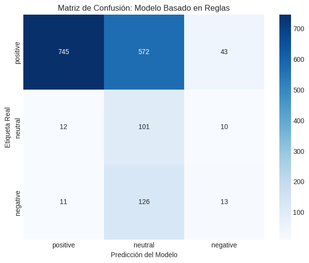

```
🔍 EJEMPLOS DE ERRORES (Para revisión):
------------------------------------------------------------
Reseña: 'Delicious!!!...'
   ➡ Real: positive | Predicho: neutral
--------------------
Reseña: 'Nice place to have coffee...'
   ➡ Real: positive | Predicho: neutral
--------------------
Reseña: 'The coffee is divine! The decor and location are perfect! The level of service is outstanding, thanks to the owners and waiters! The cakes are simply the best! Amazing! A great place for breakfast, sn...'
   ➡ Real: positive | Predicho: neutral
--------------------
```

```python
# Validación con Etiquetas Reales
if 'expected_sentiment' in df.columns:
    print("\n VALIDACIÓN")
    print("=" * 60)

    # Cálculo de Accuracy
    matches = (df['keyword_sentiment'] == df['expected_sentiment']).sum()
    accuracy = (matches / len(df)) * 100
    print(f"Exactitud (Accuracy): {accuracy:.2f}% ({matches}/{len(df)} aciertos)\n")

    # Matriz de Confusión (Texto)
    print("MATRIZ DE CONFUSIÓN (Real vs Predicho):")
    print("-" * 45)
    print(f"{'':15} {'PREDICHO':^30}")
    print(f"{'REAL':10} | {'Positive':^8} {'Neutral':^8} {'Negative':^8}")
    print("-" * 45)

    for expected in ['positive', 'neutral', 'negative']:
        print(f"{expected:10} |", end="")
        for detected in ['positive', 'neutral', 'negative']:
            count = len(df[(df['expected_sentiment'] == expected) &
                           (df['keyword_sentiment'] == detected)])
            print(f" {count:^8}", end="")
        print()

    # Visualización Gráfica (Opcional pero recomendada)
    try:
        plt.figure(figsize=(8, 6))
        labels = ['positive', 'neutral', 'negative']
        cm = confusion_matrix(df['expected_sentiment'], df['keyword_sentiment'], labels=labels)
        sns.heatmap(cm, annot=True, fmt='d', cmap='Blues', xticklabels=labels, yticklabels=labels)
        plt.title('Matriz de Confusión: Modelo Basado en Reglas')
        plt.xlabel('Predicción del Modelo')
        plt.ylabel('Etiqueta Real')
        plt.show()
    except Exception as e:
        print("\n(No se pudo generar el gráfico de matriz de confusión: falta librería o datos)")

    # Análisis de Errores (Discrepancias)
    discrepancies = df[df['keyword_sentiment'] != df['expected_sentiment']]
    if not discrepancies.empty:
        print("\n🔍 EJEMPLOS DE ERRORES (Para revisión):")
        print("-" * 60)
        # Mostrar 3 ejemplos aleatorios de error
        sample_errors = discrepancies.sample(min(3, len(discrepancies)))
        for idx, row in sample_errors.iterrows():
            print(f"Reseña: '{row['review_text'][:200]}...'")
            print(f"   ➡ Real: {row['expected_sentiment']} | Predicho: {row['keyword_sentiment']}")
            print("-" * 20)
```

### Modelo 2: VADER (Valence Aware Dictionary and Sentiment Reasoner)

```python
# Inicializar VADER
sia = SentimentIntensityAnalyzer()

def vader_sentiment_analysis(text):
    """Análisis con VADER - especializado en redes sociales"""
    scores = sia.polarity_scores(text)

    # VADER devuelve compound score entre -1 y 1
    if scores['compound'] >= 0.05:
        return 'positive'
    elif scores['compound'] <= -0.05:
        return 'negative'
    else:
        return 'neutral'

# Aplicar VADER
print(" Analizando con VADER...")
df['vader_sentiment'] = df['review_text'].apply(vader_sentiment_analysis)
df['vader_scores'] = df['review_text'].apply(lambda x: sia.polarity_scores(x))
df['vader_compound'] = df['vader_scores'].apply(lambda x: x['compound'])

print(" Análisis VADER completado")
print(f"\nDistribución VADER:")
print(df['vader_sentiment'].value_counts())
```

```
 Analizando con VADER...
 Análisis VADER completado

Distribución VADER:
vader_sentiment
positive    1430
negative     110
neutral       93
Name: count, dtype: int64
```

### Modelo 3: TextBlob

```python
def textblob_sentiment_analysis(text):
    """Análisis con TextBlob"""
    try:
        blob = TextBlob(str(text))
        polarity = blob.sentiment.polarity

        if polarity > 0.1:
            return 'positive'
        elif polarity < -0.1:
            return 'negative'
        else:
            return 'neutral'
    except:
        return 'neutral'

# Aplicar TextBlob
print(" Analizando con TextBlob...")
df['textblob_sentiment'] = df['review_text'].apply(textblob_sentiment_analysis)
df['textblob_polarity'] = df['review_text'].apply(lambda x: TextBlob(str(x)).sentiment.polarity)

print(" Análisis TextBlob completado")
print(f"\nDistribución TextBlob:")
print(df['textblob_sentiment'].value_counts())
```

```
 Analizando con TextBlob...
 Análisis TextBlob completado

Distribución TextBlob:
textblob_sentiment
positive    1415
neutral      120
negative      98
Name: count, dtype: int64
```

```python
# 1. Cargar el modelo
print(" Cargando modelo spaCy...")
try:
    # Intentamos el modelo transformer si está instalado
    nlp = spacy.load("en_core_web_trf")
    print(" Usando modelo transformer (RoBERTa)")
except:
    # Si no, usamos el modelo small (más rápido para 1665 reseñas)
    nlp = spacy.load("en_core_web_sm")
    print(" Usando modelo small")

def spacy_sentiment_analysis(text):
    """Análisis con spaCy basado en polaridad de palabras y entidades"""
    if not text:
        return 'neutral'

    doc = nlp(text[:1000])  # Mantenemos el límite de caracteres por doc para evitar cuelgues

    pos_score = 0
    neg_score = 0

    # Análisis por tokens (usando los diccionarios unificados de pasos anteriores)
    for token in doc:
        token_lower = token.text.lower()
        if token_lower in positive_words:
            pos_score += 1
        elif token_lower in negative_words:
            neg_score += 1

    # Análisis de contexto de entidades (Lugares/Productos)
    for ent in doc.ents:
        if ent.label_ in ['ORG', 'PRODUCT', 'GPE']:
            context = text[max(0, ent.start_char-20):min(len(text), ent.end_char+20)].lower()
            if any(word in context for word in ['great', 'excellent', 'best', 'good']):
                pos_score += 0.5
            elif any(word in context for word in ['terrible', 'worst', 'awful', 'bad']):
                neg_score += 0.5

    # Clasificación final
    if pos_score > neg_score + 1:
        return 'positive'
    elif neg_score > pos_score + 1:
        return 'negative'
    else:
        return 'neutral'

# 2. Aplicar a TODO el dataset (sin .head() ni muestras)
print(f" Analizando {len(df)} reseñas con spaCy..")

# Usamos progress_apply si tienes tqdm, o apply normal:
df['sentiment_spacy'] = df['review_text'].apply(spacy_sentiment_analysis)

print(f" Análisis spaCy completado para {len(df)} reseñas")
print(f"\nDistribución spaCy:")
print(df['sentiment_spacy'].value_counts())
```

```
 Cargando modelo spaCy...
 Usando modelo small
 Analizando 1633 reseñas con spaCy..
 Análisis spaCy completado para 1633 reseñas

Distribución spaCy:
sentiment_spacy
positive    919
neutral     683
negative     31
Name: count, dtype: int64
```

### Modelo 5: BERT (Transformers)

```python
print(" Cargando modelo BERT...")

# 1. Configuración del dispositivo (GPU si está disponible)
device = 0 if torch.cuda.is_available() else -1
print(f"Usando: {' GPU' if device == 0 else '💻 CPU'}")

model_name = "nlptown/bert-base-multilingual-uncased-sentiment"

try:
    classifier = pipeline(
        "sentiment-analysis",
        model=model_name,
        device=device
    )

    # 2. Preparar los datos
    texts = df['review_text'].str[:512].tolist() # BERT tiene límite de 512 tokens
    total_reviews = len(texts)

    # 3. Procesamiento en lotes para eficiencia
    batch_size = 16
    bert_sentiments = []

    print(f" Analizando {total_reviews} reseñas con BERT...")

    for i in range(0, total_reviews, batch_size):
        batch = texts[i : i + batch_size]

        try:
            results = classifier(batch)
            for result in results:
                label = result['label']
                # Mapeo de 1-5 estrellas a sentimiento textual
                if label in ['1 star', '2 stars']:
                    bert_sentiments.append('negative')
                elif label == '3 stars':
                    bert_sentiments.append('neutral')
                else:  # 4 o 5 stars
                    bert_sentiments.append('positive')
        except Exception as e:
            # En caso de error en un lote específico, llenamos con neutral
            bert_sentiments.extend(['neutral'] * len(batch))

        # Reporte de progreso cada 200 reseñas
        if (i + batch_size) % 200 == 0 or (i + batch_size) >= total_reviews:
            print(f"   ✓ Procesadas {min(i + batch_size, total_reviews)}/{total_reviews} reseñas...")

    # 4. Asignar resultados al DataFrame original
    df['sentiment_bert'] = bert_sentiments

    print(f"\n Análisis BERT completado para {len(df)} reseñas")
    print(f" Distribución BERT:")
    print(df['sentiment_bert'].value_counts())

    BERT_AVAILABLE = True

except Exception as e:
    print(f" Error con BERT: {e}")
    BERT_AVAILABLE = False
```

```
 Cargando modelo BERT...
Usando:  GPU
```

```
vocab.txt: 0.00B [00:00, ?B/s]
```

```
 Analizando 1633 reseñas con BERT...
```

```
You seem to be using the pipelines sequentially on GPU. In order to maximize efficiency please use a dataset
```

```
   ✓ Procesadas 400/1633 reseñas...
   ✓ Procesadas 800/1633 reseñas...
   ✓ Procesadas 1200/1633 reseñas...
   ✓ Procesadas 1600/1633 reseñas...
   ✓ Procesadas 1633/1633 reseñas...

 Análisis BERT completado para 1633 reseñas
 Distribución BERT:
sentiment_bert
positive    1394
negative     149
neutral       90
Name: count, dtype: int64
```

### Modelo 6: BERTopic

```python
# 1. INSTALACIÓN DE LIBRERÍAS
!pip install bertopic
!pip install transformers
!pip install torch
!pip install nltk
!pip install openpyxl

# 2. IMPORTACIONES
import pandas as pd
import numpy as np
import re
from tqdm import tqdm
import nltk
from nltk.corpus import stopwords
from nltk.tokenize import word_tokenize
from nltk.stem import WordNetLemmatizer
from sklearn.feature_extraction.text import CountVectorizer
from bertopic import BERTopic
from transformers import pipeline, AutoTokenizer, AutoModelForMaskedLM
import torch

# Descargas de NLTK
nltk.download('stopwords', quiet=True)
nltk.download('punkt', quiet=True)
nltk.download('averaged_perceptron_tagger', quiet=True)
nltk.download('wordnet', quiet=True)
nltk.download('omw-1.4', quiet=True)

print(" Librerías instaladas y cargadas.")
```

```
Downloading bertopic-0.17.4-py3-none-any.whl (154 kB)
   ━━━━━━━━━━━━━━━━━━━━━━━━━━━━━━━━━━━━━━━━ 154.7/154.7 kB 11.3 MB/s eta 0:00:00
 Librerías instaladas y cargadas.
```

```python
# ==============================================================================
# FASE 1: PREPROCESAMIENTO
# ==============================================================================

lemmatizer = WordNetLemmatizer()
stop_words = set(stopwords.words('english'))

# Stopwords personalizadas (Mínimas para no borrar info valiosa)
custom_stops = {
    'really', 'very', 'go', 'get', 'also', 'would', 'could', 'should',
    'make', 'much', 'even', 'place', 'restaurant'
}
stop_words.update(custom_stops)

# Descarga adicional de NLTK para punkt_tab y averaged_perceptron_tagger
nltk.download('punkt_tab', quiet=True)
nltk.download('averaged_perceptron_tagger_eng', quiet=True)

def clean_text_advanced(text):
    if pd.isna(text) or text is None: return ""
    text = str(text).lower()
    text = re.sub(r'http\S+|www\S+|https\S+', '', text) # URLs
    text = re.sub(r'\S+@\S+', '', text) # Emails
    text = re.sub(r'[^a-z\s\']', ' ', text) # Solo letras y apostrofes
    text = re.sub(r'\s+', ' ', text).strip() # Espacios
    return text

def filter_by_pos(text):
    """Filtra manteniendo sustantivos, adjetivos, verbos y adverbios"""
    if not text: return ""
    keep_pos = ['NN', 'NNS', 'NNP', 'NNPS', 'JJ', 'JJR', 'JJS', 'VB', 'VBG', 'RB']

    tokens = word_tokenize(text)
    pos_tags = nltk.pos_tag(tokens)

    filtered = [
        lemmatizer.lemmatize(word)
        for word, pos in pos_tags
        if pos in keep_pos and word not in stop_words and len(word) > 1
    ]
    return " ".join(filtered)

print("Limpiando y procesando textos...")

# Aplicamos al dataframe existente
# Usamos tu columna 'review_text' como base (que ya limpiamos de traducciones antes)
df['text_clean_base'] = df['review_text'].apply(clean_text_advanced)
df['text_for_bertopic_pos'] = df['text_clean_base'].apply(filter_by_pos)

# Filtramos las que hayan quedado vacías
df_topics = df[df['text_for_bertopic_pos'].str.len() > 2].copy()
print(f" Textos procesados. Reseñas listas: {len(df_topics)}")
```

```
Limpiando y procesando textos...
 Textos procesados. Reseñas listas: 1627
```

```python
# ==============================================================================
# FASE 2: CLASIFICACIÓN POR CATEGORÍAS (Zero-Shot)
# ==============================================================================

categories = [
    "coffee quality",
    "food quality",
    "service and staff",
    "atmosphere and ambiance",
    "location and accessibility",
    "price and value"
]

print(" Cargando modelo de clasificación (puede tardar)...")
# Usamos GPU si está disponible
device = 0 if torch.cuda.is_available() else -1

classifier = pipeline(
    "zero-shot-classification",
    model="microsoft/deberta-v2-xlarge-mnli",
    # Si falla por memoria, usa: "valhalla/distilbart-mnli-12-3"
    device=device
)

def batch_classify_reviews(texts, batch_size=8, threshold=0.5): # Batch más pequeño por seguridad
    all_categories = []

    for i in tqdm(range(0, len(texts), batch_size), desc="Clasificando"):
        batch = texts[i:i+batch_size]
        batch_results = [[] for _ in range(len(batch))]

        valid_indices = [j for j, t in enumerate(batch) if len(str(t).strip()) > 3]
        valid_batch = [batch[j] for j in valid_indices]

        if not valid_batch:
            all_categories.extend(batch_results)
            continue

        try:
            results = classifier(
                valid_batch,
                categories,
                multi_label=True,
                hypothesis_template="This review discusses {}."
            )

            if not isinstance(results, list): results = [results]

            for idx, res in zip(valid_indices, results):
                cats = [label for label, score in zip(res['labels'], res['scores']) if score >= threshold]
                batch_results[idx] = cats

        except Exception as e:
            print(f"Error en batch {i}: {e}")

        all_categories.extend(batch_results)

    return all_categories

# Ejecutar clasificación
print("⏳ Clasificando reseñas")
# Usamos un umbral de 0.85 para que solo clasifique si está muy seguro
df_topics['categories'] = batch_classify_reviews(
    df_topics['text_clean_base'].tolist(),
    batch_size=8,
    threshold=0.85
)

# Verificación rápida
for cat in categories:
    count = df_topics['categories'].apply(lambda x: cat in x).sum()
    print(f"  -> {cat}: {count} reseñas")
```

```
 Cargando modelo de clasificación (puede tardar)...
```

```
⏳ Clasificando reseñas
```

```
  -> coffee quality: 743 reseñas
  -> food quality: 633 reseñas
  -> service and staff: 461 reseñas
  -> atmosphere and ambiance: 648 reseñas
  -> location and accessibility: 497 reseñas
  -> price and value: 518 reseñas
```

```python
# ==============================================================================
# FASE 3 MEJORADA: BERTopic CON LIMPIEZA CONTEXTUAL
# ==============================================================================

# 1. Configuración de Stopwords Inteligentes
# Quitamos la palabra obvia de cada categoría para ver los detalles reales
category_stopwords = {
    "coffee quality": ["coffee", "cafe", "cup", "drink", "flavor"],
    "food quality": ["food", "eat", "meal", "dish", "menu"],
    "service and staff": ["service", "staff", "waiter", "waitress", "people", "attention"],
    "price and value": ["price", "money", "value", "expensive", "cheap", "cost"],
    "atmosphere and ambiance": ["atmosphere", "place", "spot", "ambiance", "vibe", "decor"],
    "location and accessibility": ["location", "place", "near", "area"]
}

# Stopwords base + ruido genérico ("excellent excellent")
base_stopwords = list(stopwords.words('english'))
generic_noise = ["good", "great", "nice", "excellent", "amazing", "really", "very", "best", "bad"]

# Diccionarios para guardar resultados
all_topics_detailed = {}
category_insights = {}

print("📊 Iniciando análisis de tópicos REFINADO...")

for category in categories:
    print(f"\n--- {category.upper()} ---")

    # 2. Filtrar reseñas de esta categoría
    cat_reviews = df_topics[df_topics['categories'].apply(lambda x: category in x)]

    if len(cat_reviews) < 10:
        print(f"⚠️ Saltando: pocas reseñas específicas ({len(cat_reviews)}).")
        category_insights[category] = {'keywords': []}
        continue

    print(f"  -> Analizando {len(cat_reviews)} reseñas específicas.")

    # 3. Configurar Vectorizer ÚNICO para esta categoría
    # Unimos: base + ruido genérico + palabras obvias de ESTA categoría
    current_stopwords = base_stopwords + generic_noise + category_stopwords.get(category, [])

    vectorizer_model = CountVectorizer(
        stop_words=current_stopwords,
        min_df=2,
        ngram_range=(1, 2)
    )

    # 4. Entrenar BERTopic
    topic_model = BERTopic(
        embedding_model="all-MiniLM-L6-v2",
        vectorizer_model=vectorizer_model,
        nr_topics="auto",
        min_topic_size=3,
        verbose=False
    )

    try:
        texts = cat_reviews['text_for_bertopic_pos'].tolist()
        topics, probs = topic_model.fit_transform(texts)

        # 5. Guardar y mostrar resultados limpios
        freq = topic_model.get_topic_info()
        freq = freq[freq['Topic'] != -1]

        # Guardar para insights
        all_keywords_list = []
        cat_topics_data = []

        for idx, row in freq.iterrows():
            topic_id = row['Topic']
            # Extraer palabras
            words = [w[0] for w in topic_model.get_topic(topic_id)]
            all_keywords_list.extend(words)

            # Guardar datos del tópico
            cat_topics_data.append({
                'topic_id': topic_id,
                'count': row['Count'],
                'keywords': ", ".join(words[:7])
            })

            # Mostrar solo los 3 primeros tópicos para no saturar pantalla
            if idx < 3:
                print(f"  ✨ Tópico {topic_id}: {', '.join(words[:5])}")

        category_insights[category] = {'keywords': list(set(all_keywords_list))}
        all_topics_detailed[category] = pd.DataFrame(cat_topics_data)

    except Exception as e:
        print(f"  ❌ No se pudieron generar tópicos: {e}")
        category_insights[category] = {'keywords': []}

print("\n✅ Análisis completado con filtros de calidad.")
```

```
📊 Iniciando análisis de tópicos REFINADO...

--- COFFEE QUALITY ---
  -> Analizando 743 reseñas específicas.
```

[output not shown]

```
  ✨ Tópico 0: delicious, breakfast, staff, service, friendly
  ✨ Tópico 1: caixa, caixaforum, caixa forum, forum, next

--- FOOD QUALITY ---
  -> Analizando 633 reseñas específicas.
```

[output not shown]

```
  ✨ Tópico 0: breakfast, coffee, atmosphere, ham, service
  ✨ Tópico 1: madrid, prado, museum, station, paseo

--- SERVICE AND STAFF ---
  -> Analizando 461 reseñas específicas.
```

[output not shown]

```
  ✨ Tópico 0: coffee, coffee coffee, coffee delicious, atmosphere, friendly coffee
  ✨ Tópico 1: food, highly, fantastic, friendly, attentive

--- ATMOSPHERE AND AMBIANCE ---
  -> Analizando 648 reseñas específicas.
```

[output not shown]

```
  ✨ Tópico 0: coffee, service coffee, service, coffee coffee, delicious coffee
  ✨ Tópico 1: breakfast, recommended, snack, quick, ham

--- LOCATION AND ACCESSIBILITY ---
  -> Analizando 497 reseñas específicas.
```

[output not shown]

```
  ✨ Tópico 0: coffee, coffee service, service, staff coffee, staff
  ✨ Tópico 1: madrid, chai latte, chai, back, come back

--- PRICE AND VALUE ---
  -> Analizando 518 reseñas específicas.
```

[output not shown]

```
  ✨ Tópico 0: coffee, breakfast, service, delicious, staff
  ✨ Tópico 1: madrid, museum, prado, coffee, day

✅ Análisis completado con filtros de calidad.
```

[figure not shown]

```
✅ Visualización de palabras clave generada
```

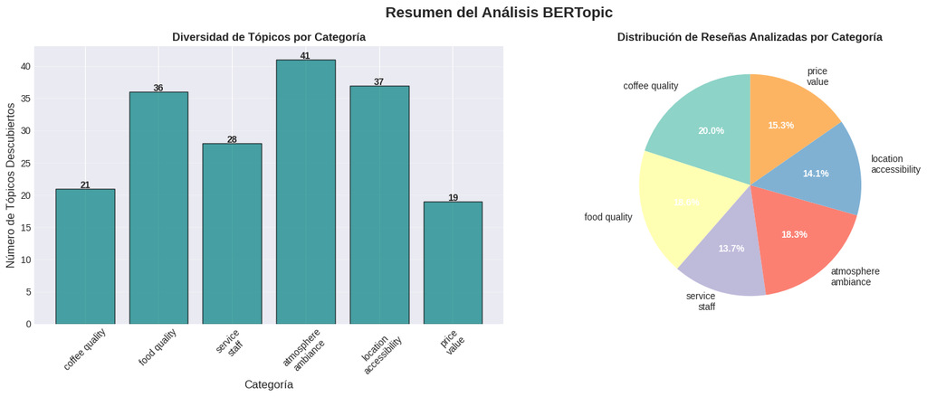

```
✅ Visualización de resumen generada

============================================================
📊 TODAS LAS VISUALIZACIONES DE BERTOPIC COMPLETADAS
============================================================
```

```python
# ==============================================================================
# VISUALIZACIÓN DE RESULTADOS DE BERTOPIC
# ==============================================================================

# ==============================================================================
# VISUALIZACIÓN: RESUMEN DE CATEGORÍAS Y PALABRAS CLAVE
# ==============================================================================

# Crear un resumen visual de las palabras clave más relevantes por categoría
fig, axes = plt.subplots(2, 3, figsize=(18, 10))
axes_flat = axes.flatten()

for idx, category in enumerate(categories[:6]):  # Máximo 6 categorías
    ax = axes_flat[idx]

    if category in category_insights and category_insights[category]['keywords']:
        keywords = category_insights[category]['keywords'][:15]  # Top 15 keywords

        # Contar frecuencia aproximada (simplificado)
        keyword_freq = {kw: len(kw) for kw in keywords}  # Placeholder para frecuencia real

        # Crear gráfico de barras horizontales
        sorted_keywords = sorted(keyword_freq.items(), key=lambda x: x[1], reverse=True)[:10]
        words = [w[0] for w in sorted_keywords]
        freqs = [w[1] for w in sorted_keywords]

        ax.barh(range(len(words)), freqs, color='coral', alpha=0.7)
        ax.set_yticks(range(len(words)))
        ax.set_yticklabels(words, fontsize=10)
        ax.set_xlabel('Relevancia')
        ax.set_title(f'{category.title()}', fontweight='bold')
        ax.grid(True, alpha=0.3, axis='x')

        # Invertir el eje y para que las palabras más relevantes estén arriba
        ax.invert_yaxis()
    else:
        ax.text(0.5, 0.5, f'{category.title()}\n(Sin datos)',
               ha='center', va='center', transform=ax.transAxes, fontsize=12)
        ax.set_xticks([])
        ax.set_yticks([])

plt.suptitle('Palabras Clave Principales por Aspecto del Negocio', fontsize=16, fontweight='bold')
plt.tight_layout()
plt.show()

print("✅ Visualización de palabras clave generada")

# ==============================================================================
# VISUALIZACIÓN 2: DISTRIBUCIÓN DE TÓPICOS POR CATEGORÍA
# ==============================================================================

# Crear un DataFrame resumen para visualización
summary_data = []
for category in categories:
    if category in all_topics_detailed and not all_topics_detailed[category].empty:
        num_topics = len(all_topics_detailed[category])
        total_reviews = all_topics_detailed[category]['count'].sum()
        summary_data.append({
            'Category': category.replace(' and ', '\n'),
            'Topics': num_topics,
            'Reviews': total_reviews
        })

if summary_data:
    df_summary = pd.DataFrame(summary_data)

    fig, (ax1, ax2) = plt.subplots(1, 2, figsize=(15, 6))

    # Gráfico 1: Número de tópicos por categoría
    ax1.bar(df_summary['Category'], df_summary['Topics'],
           color='teal', alpha=0.7, edgecolor='black')
    ax1.set_xlabel('Categoría', fontsize=12)
    ax1.set_ylabel('Número de Tópicos Descubiertos', fontsize=12)
    ax1.set_title('Diversidad de Tópicos por Categoría', fontweight='bold')
    ax1.grid(True, alpha=0.3, axis='y')
    ax1.tick_params(axis='x', rotation=45)

    # Añadir valores en las barras
    for i, v in enumerate(df_summary['Topics']):
        ax1.text(i, v + 0.1, str(v), ha='center', fontweight='bold')

    # Gráfico 2: Distribución de reseñas analizadas
    colors = plt.cm.Set3(range(len(df_summary)))
    wedges, texts, autotexts = ax2.pie(df_summary['Reviews'],
                                        labels=df_summary['Category'],
                                        colors=colors,
                                        autopct='%1.1f%%',
                                        startangle=90)

    # Mejorar el texto
    for autotext in autotexts:
        autotext.set_color('white')
        autotext.set_fontweight('bold')

    ax2.set_title('Distribución de Reseñas Analizadas por Categoría', fontweight='bold')

    plt.suptitle('Resumen del Análisis BERTopic', fontsize=16, fontweight='bold')
    plt.tight_layout()
    plt.show()

    print("✅ Visualización de resumen generada")

print("\n" + "="*60)
print("📊 TODAS LAS VISUALIZACIONES DE BERTOPIC COMPLETADAS")
print("="*60)
```

```python
# ==============================================================================
# FASE 4 MEJORADA: GENERACIÓN DE INSIGHTS (Filtrado Inteligente)
# ==============================================================================

mask_filler = pipeline("fill-mask", model="bert-base-uncased", device=device)

# 1. Templates DESCRIPTIVOS (Evitan consejos locos como "hazlo más caro")
sentence_templates = {
    'coffee quality': [
        "Reviewers say the coffee taste is [MASK].",  # Sabor
        "The coffee is described as [MASK]."           # Descripción general
    ],
    'food quality': [
        "Customers mention the food is [MASK].",
        "The food quality is considered [MASK]."
    ],
    'service and staff': [
        "The staff is described as [MASK].",
        "The service provided is [MASK]."
    ],
    'atmosphere and ambiance': [
        "The atmosphere is [MASK].",
        "The place feels [MASK]."
    ],
    'price and value': [
        "Customers describe the prices as [MASK].",   # Aquí sí queremos saber si es caro
        "The value for money is [MASK]."
    ],
    'location and accessibility': [
        "The location is [MASK].",
        "Getting to the place is [MASK]."
    ]
}

# 2. Blacklist de palabras "inútiles" o confusas para insights
# Eliminamos palabras que gramaticalmente encajan pero no dicen nada útil
ignore_words = {
    "normal", "important", "rich", "smooth", "well", "also", "much", "even",
    "coffee", "food", "place", "thing", "something", "really", "very",
    "expensive", "cheap", "high", "low" # Quitamos precio de otras categorías
}

# Solo permitimos "expensive/cheap/high/low" en la categoría de PRECIO
price_keywords = {"expensive", "cheap", "reasonable", "high", "low", "fair", "good"}

def generate_insights(template, candidate_keywords, category):
    if not candidate_keywords: return []

    try:
        # Pedimos muchas opciones para filtrar después
        preds = mask_filler(template, top_k=150)
    except:
        return []

    valid_insights = []
    keywords_lower = set([k.lower() for k in candidate_keywords])

    for pred in preds:
        token = pred['token_str'].strip().lower()

        # FILTROS DE CALIDAD:
        # 1. Debe ser una palabra detectada en los tópicos
        if token not in keywords_lower: continue

        # 2. No debe ser una palabra ignorada (salvo excepciones de precio)
        if category != 'price and value' and token in ignore_words: continue

        # 3. Debe tener longitud suficiente
        if len(token) < 3: continue

        # 4. Si es categoría precio, solo aceptamos adjetivos de precio
        if category == 'price and value' and token not in price_keywords:
             # A veces "delicious" se cuela en precio, lo evitamos
             continue

        # Formato de salida limpio
        valid_insights.append(f"{pred['sequence']} (Confianza: {pred['score']:.1%})")
        if len(valid_insights) >= 3: break

    return valid_insights

print("\n==========================================")
print(" REPORT DE PERCEPCIÓN DEL CLIENTE (Final)")
print("==========================================\n")

for category, data in category_insights.items():
    if not data.get('keywords'): continue

    print(f"📊 {category.upper()}")
    # Mostramos keywords base para entender de dónde saca la info
    print(f"   (Keywords base: {', '.join(data['keywords'][:5])}...)")

    templates = sentence_templates.get(category, [])
    for tmpl in templates:
        suggestions = generate_insights(tmpl, data['keywords'], category)
        if suggestions:
            print(f"  ❓ {tmpl}")
            for s in suggestions:
                print(f"     👉 {s}")
    print("-" * 40)
```

[output not shown]

```
==========================================
 REPORT DE PERCEPCIÓN DEL CLIENTE (Final)
==========================================

📊 COFFEE QUALITY
   (Keywords base: vertical garden, , price, surprise, modern...)
  ❓ Reviewers say the coffee taste is [MASK].
     👉 reviewers say the coffee taste is pleasant. (Confianza: 2.6%)
     👉 reviewers say the coffee taste is delicious. (Confianza: 1.7%)
     👉 reviewers say the coffee taste is different. (Confianza: 1.6%)
  ❓ The coffee is described as [MASK].
     👉 the coffee is described as delicious. (Confianza: 2.2%)
     👉 the coffee is described as cool. (Confianza: 1.1%)
     👉 the coffee is described as pleasant. (Confianza: 0.7%)
----------------------------------------
📊 FOOD QUALITY
   (Keywords base: , certainly, lunch, price, touristy...)
  ❓ Customers mention the food is [MASK].
     👉 customers mention the food is delicious. (Confianza: 19.5%)
     👉 customers mention the food is free. (Confianza: 0.9%)
     👉 customers mention the food is better. (Confianza: 0.8%)
  ❓ The food quality is considered [MASK].
     👉 the food quality is considered fair. (Confianza: 0.5%)
     👉 the food quality is considered better. (Confianza: 0.3%)
     👉 the food quality is considered reasonable. (Confianza: 0.3%)
----------------------------------------
📊 SERVICE AND STAFF
   (Keywords base: , breakfast coffee, vertical garden, price, delicious beautifully...)
  ❓ The staff is described as [MASK].
     👉 the staff is described as simple. (Confianza: 2.0%)
     👉 the staff is described as small. (Confianza: 1.5%)
     👉 the staff is described as beautiful. (Confianza: 1.0%)
  ❓ The service provided is [MASK].
     👉 the service provided is free. (Confianza: 68.0%)
     👉 the service provided is fast. (Confianza: 0.5%)
     👉 the service provided is simple. (Confianza: 0.3%)
----------------------------------------
📊 ATMOSPHERE AND AMBIANCE
   (Keywords base: vertical garden, , perfect, modern, family...)
  ❓ The atmosphere is [MASK].
```

[output cut: 13 more lines]

```
     👉 the location is free. (Confianza: 0.0%)
  ❓ Getting to the place is [MASK].
     👉 getting to the place is easy. (Confianza: 64.8%)
     👉 getting to the place is hard. (Confianza: 5.4%)
     👉 getting to the place is simple. (Confianza: 1.2%)
----------------------------------------
📊 PRICE AND VALUE
   (Keywords base: , soon, stop, hour, modern...)
  ❓ Customers describe the prices as [MASK].
     👉 customers describe the prices as high. (Confianza: 9.9%)
     👉 customers describe the prices as reasonable. (Confianza: 1.6%)
  ❓ The value for money is [MASK].
     👉 the value for money is high. (Confianza: 1.4%)
     👉 the value for money is reasonable. (Confianza: 0.1%)
----------------------------------------
```

```python
# ==============================================================================
# VISUALIZACIONES BERTOPIC - ANÁLISIS INTERACTIVO DE TÓPICOS
# ==============================================================================

print(" Generando visualizaciones BERTopic para análisis profundo...")
print("="*70)

# Diccionario para almacenar modelos de cada categoría
category_models = {}
category_visualizations = {}

# Re-entrenar modelos si es necesario para generar visualizaciones
for category in categories:
    print(f"\n Procesando visualizaciones para: {category.upper()}")

    # Filtrar reseñas de esta categoría
    cat_reviews = df_topics[df_topics['categories'].apply(lambda x: category in x)]

    if len(cat_reviews) < 10:
        print(f" Saltando: muy pocas reseñas ({len(cat_reviews)})")
        continue

    # Configurar stopwords específicas
    current_stopwords = base_stopwords + generic_noise + category_stopwords.get(category, [])

    vectorizer_model = CountVectorizer(
        stop_words=current_stopwords,
        min_df=2,
        ngram_range=(1, 2)
    )

    # Crear modelo BERTopic
    topic_model = BERTopic(
        embedding_model="all-MiniLM-L6-v2",
        vectorizer_model=vectorizer_model,
        nr_topics="auto",
        min_topic_size=5,
        verbose=False
    )

    try:
        texts = cat_reviews['text_for_bertopic_pos'].tolist()
        topics, probs = topic_model.fit_transform(texts)

        # Guardar el modelo
        category_models[category] = {
            'model': topic_model,
            'topics': topics,
            'probs': probs,
            'texts': texts
        }

        print(f"  Modelo listo para visualización ({len(set(topics))-1} tópicos encontrados)")

    except Exception as e:
        print(f"  Error al crear modelo para visualización: {e}")

print("\n Modelos preparados para visualización interactiva")
```

```
 Generando visualizaciones BERTopic para análisis profundo...
======================================================================

 Procesando visualizaciones para: COFFEE QUALITY
```

[output not shown]

```
  Modelo listo para visualización (10 tópicos encontrados)

 Procesando visualizaciones para: FOOD QUALITY
```

[output not shown]

```
  Modelo listo para visualización (28 tópicos encontrados)

 Procesando visualizaciones para: SERVICE AND STAFF
```

[output not shown]

```
  Modelo listo para visualización (25 tópicos encontrados)

 Procesando visualizaciones para: ATMOSPHERE AND AMBIANCE
```

[output not shown]

```
  Modelo listo para visualización (8 tópicos encontrados)

 Procesando visualizaciones para: LOCATION AND ACCESSIBILITY
```

[output not shown]

```
  Modelo listo para visualización (17 tópicos encontrados)

 Procesando visualizaciones para: PRICE AND VALUE
```

[output not shown]

```
  Modelo listo para visualización (20 tópicos encontrados)

 Modelos preparados para visualización interactiva
```

```python
# ==============================================================================
# VISUALIZACIÓN 1: MAPA DE DISTANCIA ENTRE TÓPICOS
# ==============================================================================

print("\n MAPAS DE DISTANCIA ENTRE TÓPICOS")
print("-"*70)

for category, model_data in category_models.items():
    if model_data:
        try:
            print(f"\n {category.upper()}")
            topic_model = model_data['model']

            # Generar visualización de distancia entre tópicos
            fig = topic_model.visualize_topics()

            # Personalizar el título
            fig.update_layout(
                title=f"Mapa de Tópicos - {category.upper()}",
                title_font_size=16,
                showlegend=True,
                width=800,
                height=600
            )

            fig.show()

        except Exception as e:
            print(f"   No se pudo generar mapa de distancia: {e}")
```

```
 MAPAS DE DISTANCIA ENTRE TÓPICOS
----------------------------------------------------------------------

 COFFEE QUALITY
```

[interactive chart not shown]

```
 FOOD QUALITY
```

[interactive chart not shown]

```
 SERVICE AND STAFF
```

[interactive chart not shown]

```
 ATMOSPHERE AND AMBIANCE
```

[interactive chart not shown]

```
 LOCATION AND ACCESSIBILITY
```

[interactive chart not shown]

```
 PRICE AND VALUE
```

[interactive chart not shown]

```python
# ==============================================================================
# VISUALIZACIÓN 2: GRÁFICO DE BARRAS DE PALABRAS CLAVE POR TÓPICO
# ==============================================================================

print("\n GRÁFICOS DE BARRAS - PALABRAS CLAVE POR TÓPICO")
print("-"*70)

for category, model_data in category_models.items():
    if model_data:
        try:
            print(f"\n {category.upper()}")
            topic_model = model_data['model']

            # Generar gráfico de barras
            fig = topic_model.visualize_barchart(top_n_topics=10)

            # Personalizar el título
            fig.update_layout(
                title=f"Palabras Clave por Tópico - {category.upper()}",
                title_font_size=16,
                showlegend=False,
                width=1000,
                height=600
            )

            fig.show()

        except Exception as e:
            print(f"   No se pudo generar gráfico de barras: {e}")
```

```
 GRÁFICOS DE BARRAS - PALABRAS CLAVE POR TÓPICO
----------------------------------------------------------------------

 COFFEE QUALITY
```

[interactive chart not shown]

```
 FOOD QUALITY
```

[interactive chart not shown]

```
 SERVICE AND STAFF
```

[interactive chart not shown]

```
 ATMOSPHERE AND AMBIANCE
```

[interactive chart not shown]

```
 LOCATION AND ACCESSIBILITY
```

[interactive chart not shown]

```
 PRICE AND VALUE
```

[interactive chart not shown]

```python
# ==============================================================================
# VISUALIZACIÓN 3: MAPA DE CALOR DE SIMILITUD ENTRE TÓPICOS
# ==============================================================================

print("\n MAPAS DE CALOR - SIMILITUD ENTRE TÓPICOS")
print("-"*70)

for category, model_data in category_models.items():
    if model_data:
        try:
            print(f"\n {category.upper()}")
            topic_model = model_data['model']

            # Generar mapa de calor
            fig = topic_model.visualize_heatmap()

            # Personalizar el título y diseño
            fig.update_layout(
                title=f"Similitud entre Tópicos - {category.upper()}",
                title_font_size=16,
                width=800,
                height=700
            )

            fig.show()

        except Exception as e:
            print(f"   No se pudo generar mapa de calor: {e}")
```

```
 MAPAS DE CALOR - SIMILITUD ENTRE TÓPICOS
----------------------------------------------------------------------

 COFFEE QUALITY
```

[interactive chart not shown]

```
 FOOD QUALITY
```

[interactive chart not shown]

```
 SERVICE AND STAFF
```

[interactive chart not shown]

```
 ATMOSPHERE AND AMBIANCE
```

[interactive chart not shown]

```
 LOCATION AND ACCESSIBILITY
```

[interactive chart not shown]

```
 PRICE AND VALUE
```

[interactive chart not shown]

```
 ANÁLISIS ESTADÍSTICO DE TÓPICOS POR CATEGORÍA
======================================================================
```

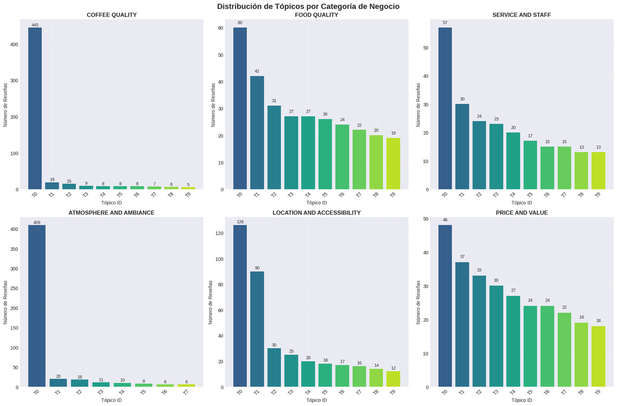

```
 RESUMEN ESTADÍSTICO DETALLADO
======================================================================
                 Categoría  Total Docs  Núm. Tópicos    Outliers Tópico Mayor
            COFFEE QUALITY         743            10 213 (28.7%)  445 (59.9%)
              FOOD QUALITY         633            28 160 (25.3%)    60 (9.5%)
         SERVICE AND STAFF         461            25 100 (21.7%)   57 (12.4%)
   ATMOSPHERE AND AMBIANCE         648             8 160 (24.7%)  409 (63.1%)
LOCATION AND ACCESSIBILITY         497            17  67 (13.5%)  126 (25.4%)
           PRICE AND VALUE         518            20 138 (26.6%)    48 (9.3%)
```

```python
# ==============================================================================
# VISUALIZACIÓN 4: DISTRIBUCIÓN DE TÓPICOS Y ANÁLISIS ESTADÍSTICO
# ==============================================================================

print("\n ANÁLISIS ESTADÍSTICO DE TÓPICOS POR CATEGORÍA")
print("="*70)

# Crear figura con subplots para comparación
fig, axes = plt.subplots(2, 3, figsize=(18, 12))
fig.suptitle('Distribución de Tópicos por Categoría de Negocio', fontsize=16, fontweight='bold')

for idx, (category, model_data) in enumerate(category_models.items()):
    if model_data and idx < 6:
        ax = axes[idx // 3, idx % 3]

        topics = model_data['topics']
        topic_model = model_data['model']

        # Obtener información de tópicos
        topic_info = topic_model.get_topic_info()
        topic_info = topic_info[topic_info['Topic'] != -1]  # Excluir outliers

        if not topic_info.empty:
            # Crear gráfico de barras con conteo de documentos por tópico
            topic_counts = topic_info['Count'].head(10)
            topic_names = [f"T{t}" for t in topic_info['Topic'].head(10)]

            bars = ax.bar(range(len(topic_counts)), topic_counts,
                         color=plt.cm.viridis(np.linspace(0.3, 0.9, len(topic_counts))))

            ax.set_xlabel('Tópico ID')
            ax.set_ylabel('Número de Reseñas')
            ax.set_title(f'{category.upper()}', fontweight='bold')
            ax.set_xticks(range(len(topic_names)))
            ax.set_xticklabels(topic_names, rotation=45)
            ax.grid(True, alpha=0.3)

            # Añadir valores en las barras
            for bar, val in zip(bars, topic_counts):
                height = bar.get_height()
                ax.text(bar.get_x() + bar.get_width()/2., height + 1,
                       f'{int(val)}', ha='center', va='bottom', fontsize=9)
        else:
            ax.text(0.5, 0.5, 'No hay datos', ha='center', va='center', transform=ax.transAxes)
            ax.set_title(f'{category.upper()}', fontweight='bold')

# Ocultar subplots vacíos si hay menos de 6 categorías
for idx in range(len(category_models), 6):
    ax = axes[idx // 3, idx % 3]
    ax.axis('off')

plt.tight_layout()
plt.show()

# Resumen estadístico detallado
print("\n RESUMEN ESTADÍSTICO DETALLADO")
print("="*70)

summary_stats = []
for category, model_data in category_models.items():
    if model_data:
        topics = model_data['topics']
        topic_model = model_data['model']

        # Calcular estadísticas
        n_topics = len(set(topics)) - 1  # Excluir -1 (outliers)
        n_outliers = (np.array(topics) == -1).sum()
        total_docs = len(topics)
        outlier_rate = (n_outliers / total_docs) * 100

        # Obtener el tópico más grande
        topic_info = topic_model.get_topic_info()
        if not topic_info.empty:
            largest_topic = topic_info[topic_info['Topic'] != -1].iloc[0]
            largest_topic_size = largest_topic['Count']
            largest_topic_pct = (largest_topic_size / total_docs) * 100
        else:
            largest_topic_size = 0
            largest_topic_pct = 0

        summary_stats.append({
            'Categoría': category.upper(),
            'Total Docs': total_docs,
            'Núm. Tópicos': n_topics,
            'Outliers': f'{n_outliers} ({outlier_rate:.1f}%)',
            'Tópico Mayor': f'{largest_topic_size} ({largest_topic_pct:.1f}%)'
        })

# Crear DataFrame con estadísticas
stats_df = pd.DataFrame(summary_stats)
print(stats_df.to_string(index=False))
```

```
 ANÁLISIS COMPARATIVO GLOBAL
======================================================================
```

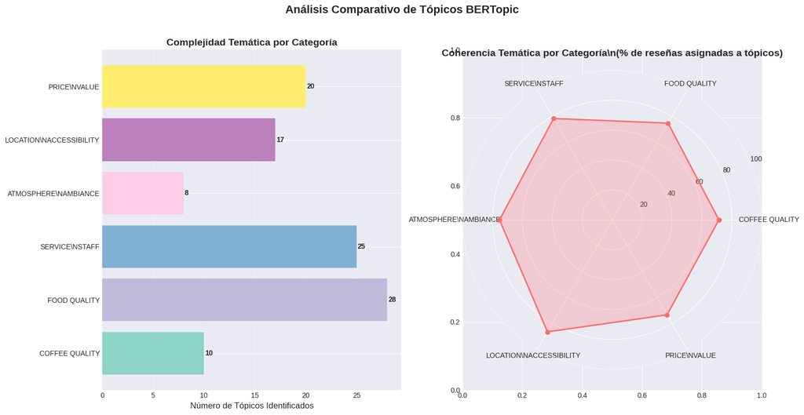

```
 INSIGHTS CLAVE POR CATEGORÍA
======================================================================

 COFFEE QUALITY
   Temas principales: service, especially, treatment, food, charming, free, free option, delicious

 FOOD QUALITY
   Temas principales: delicious coffee, service, back, people serving, coffee, service service, latte, highly service

 SERVICE AND STAFF
   Temas principales: atmosphere, breakfast coffee, toast, coffee delicious, love, center madrid, unbeatable, oatmeal

 ATMOSPHERE AND AMBIANCE
   Temas principales: service, welcoming, kindly, chance, choose, coffee, delicious, breakfast

 LOCATION AND ACCESSIBILITY
   Temas principales: service, back, chai, toast, sandwich, food, croissant, delicious

 PRICE AND VALUE
   Temas principales: service, back, rich coffee, coffee, day, coffee coffee, madrid, friendly

======================================================================
 CONCLUSIONES DEL ANÁLISIS BERTOPIC:
----------------------------------------------------------------------
1. Las categorías con más tópicos indican mayor diversidad de opiniones
2. Alta coherencia temática sugiere consenso en las experiencias de clientes
======================================================================
```

```python
# ==============================================================================
# VISUALIZACIÓN 5: ANÁLISIS COMPARATIVO GLOBAL DE TÓPICOS
# ==============================================================================

print("\n ANÁLISIS COMPARATIVO GLOBAL")
print("="*70)

# Recopilar las palabras clave más importantes de cada categoría
global_keywords = {}
for category, model_data in category_models.items():
    if model_data:
        topic_model = model_data['model']
        topic_info = topic_model.get_topic_info()

        # Obtener las palabras más importantes de los top 3 tópicos
        top_words = []
        for topic_id in topic_info[topic_info['Topic'] != -1]['Topic'].head(3):
            words = [w[0] for w in topic_model.get_topic(topic_id)][:5]
            top_words.extend(words)

        global_keywords[category] = list(set(top_words))

# Crear visualización de resumen
if global_keywords:
    fig, axes = plt.subplots(1, 2, figsize=(16, 8))

    # Subplot 1: Número de tópicos por categoría
    ax1 = axes[0]
    categories_list = []
    topic_counts = []

    for category, model_data in category_models.items():
        if model_data:
            topics = model_data['topics']
            n_topics = len(set(topics)) - 1
            categories_list.append(category.replace(' and ', '\\n').upper())
            topic_counts.append(n_topics)

    bars = ax1.barh(categories_list, topic_counts, color=plt.cm.Set3(np.linspace(0, 1, len(categories_list))))
    ax1.set_xlabel('Número de Tópicos Identificados', fontsize=12)
    ax1.set_title('Complejidad Temática por Categoría', fontsize=14, fontweight='bold')
    ax1.grid(True, alpha=0.3, axis='x')

    # Añadir valores
    for bar, val in zip(bars, topic_counts):
        width = bar.get_width()
        ax1.text(width + 0.1, bar.get_y() + bar.get_height()/2,
                f'{int(val)}', ha='left', va='center', fontweight='bold')

    # Subplot 2: Coherencia temática (basada en tasa de outliers)
    ax2 = axes[1]
    coherence_scores = []

    for category, model_data in category_models.items():
        if model_data:
            topics = model_data['topics']
            n_outliers = (np.array(topics) == -1).sum()
            total = len(topics)
            coherence = 100 - (n_outliers / total * 100)  # Inverso de outliers
            coherence_scores.append(coherence)

    # Gráfico de radar/polar para coherencia
    angles = np.linspace(0, 2 * np.pi, len(categories_list), endpoint=False).tolist()
    coherence_scores = coherence_scores + coherence_scores[:1]  # Cerrar el círculo
    angles += angles[:1]

    ax2 = plt.subplot(122, projection='polar')
    ax2.plot(angles, coherence_scores, 'o-', linewidth=2, color='#FF6B6B')
    ax2.fill(angles, coherence_scores, alpha=0.25, color='#FF6B6B')
    ax2.set_xticks(angles[:-1])
    ax2.set_xticklabels(categories_list, size=10)
    ax2.set_ylim(0, 100)
    ax2.set_title('Coherencia Temática por Categoría\\n(% de reseñas asignadas a tópicos)',
                  fontsize=14, fontweight='bold', pad=20)
    ax2.grid(True)

    plt.suptitle('Análisis Comparativo de Tópicos BERTopic', fontsize=16, fontweight='bold', y=1.02)
    plt.tight_layout()
    plt.show()

# Tabla resumen de insights clave
print("\n INSIGHTS CLAVE POR CATEGORÍA")
print("="*70)

for category, keywords in global_keywords.items():
    print(f"\n {category.upper()}")
    print(f"   Temas principales: {', '.join(keywords[:8])}")

print("\n" + "="*70)
print(" CONCLUSIONES DEL ANÁLISIS BERTOPIC:")
print("-"*70)
print("1. Las categorías con más tópicos indican mayor diversidad de opiniones")
print("2. Alta coherencia temática sugiere consenso en las experiencias de clientes")
print("="*70)
```

# Cálculo de Métricas de Evaluación

```python
def calculate_metrics(y_true, y_pred, model_name):
    """Calcula todas las métricas de evaluación para un modelo"""

    # Filtrar NaN si existen
    mask = ~(pd.isna(y_true) | pd.isna(y_pred))
    y_true = y_true[mask]
    y_pred = y_pred[mask]

    # Métricas básicas
    accuracy = accuracy_score(y_true, y_pred)
    precision = precision_score(y_true, y_pred, average='weighted', zero_division=0)
    recall = recall_score(y_true, y_pred, average='weighted', zero_division=0)
    f1 = f1_score(y_true, y_pred, average='weighted', zero_division=0)
    kappa = cohen_kappa_score(y_true, y_pred)

    # Métricas por clase
    precision_per_class = precision_score(y_true, y_pred, average=None, labels=['positive', 'neutral', 'negative'], zero_division=0)
    recall_per_class = recall_score(y_true, y_pred, average=None, labels=['positive', 'neutral', 'negative'], zero_division=0)
    f1_per_class = f1_score(y_true, y_pred, average=None, labels=['positive', 'neutral', 'negative'], zero_division=0)

    return {
        'model': model_name,
        'accuracy': accuracy,
        'precision': precision,
        'recall': recall,
        'f1_score': f1,
        'kappa': kappa,
        'precision_positive': precision_per_class[0],
        'precision_neutral': precision_per_class[1],
        'precision_negative': precision_per_class[2],
        'recall_positive': recall_per_class[0],
        'recall_neutral': recall_per_class[1],
        'recall_negative': recall_per_class[2],
        'f1_positive': f1_per_class[0],
        'f1_neutral': f1_per_class[1],
        'f1_negative': f1_per_class[2]
    }

# Primero, aseguramos de que 'true_sentiment' existe (basado en estrellas)
star_to_sentiment = {
    'ONE': 'negative', 'TWO': 'negative',
    'THREE': 'neutral',
    'FOUR': 'positive', 'FIVE': 'positive'
}
if 'starRating' in df.columns:
    df['true_sentiment'] = df['starRating'].map(star_to_sentiment)

print(" Calculando métricas de evaluación...\n")

metrics_results = []

# Definimos un diccionario con: {Nombre para la tabla: Nombre real de la columna en df}
modelos_a_evaluar = {
    'Palabras Clave': 'keyword_sentiment',
    'VADER': 'vader_sentiment',
    'TextBlob': 'textblob_sentiment',
    'spaCy': 'sentiment_spacy',
    'BERT': 'sentiment_bert'
}

for label, col_name in modelos_a_evaluar.items():
    if col_name in df.columns:
        # Solo calculamos si la columna existe en el DataFrame
        metrics_results.append(calculate_metrics(df['true_sentiment'], df[col_name], label))
    else:
        print(f" Nota: No se encontró la columna '{col_name}' para el modelo {label}")

# Crear DataFrame con métricas
if metrics_results:
    metrics_df = pd.DataFrame(metrics_results)

    # Mostrar tabla de métricas generales
    print("\n MÉTRICAS GENERALES")
    print("="*80)
    print(metrics_df[['model', 'accuracy', 'precision', 'recall', 'f1_score', 'kappa']].to_string(index=False))

    # Mostrar métricas por clase
    print("\n MÉTRICAS POR CLASE (F1-Score)")
    print("="*80)
    print(metrics_df[['model', 'f1_positive', 'f1_neutral', 'f1_negative']].to_string(index=False))
else:
    print(" No se encontraron columnas de resultados de modelos para evaluar.")
```

```
 Calculando métricas de evaluación...


 MÉTRICAS GENERALES
================================================================================
         model  accuracy  precision   recall  f1_score    kappa
Palabras Clave  0.526026   0.835496 0.526026  0.610691 0.165181
         VADER  0.851194   0.832697 0.851194  0.839909 0.428173
      TextBlob  0.860992   0.854157 0.860992  0.854777 0.479972
         spaCy  0.608696   0.886747 0.608696  0.685480 0.214354
          BERT  0.912431   0.903440 0.912431  0.907012 0.683334

 MÉTRICAS POR CLASE (F1-Score)
================================================================================
         model  f1_positive  f1_neutral  f1_negative
Palabras Clave     0.700188    0.219089     0.120370
         VADER     0.929749    0.120370     0.615385
      TextBlob     0.939099    0.246914     0.588710
         spaCy     0.768758    0.223325     0.309392
          BERT     0.962963    0.431925     0.789298
```

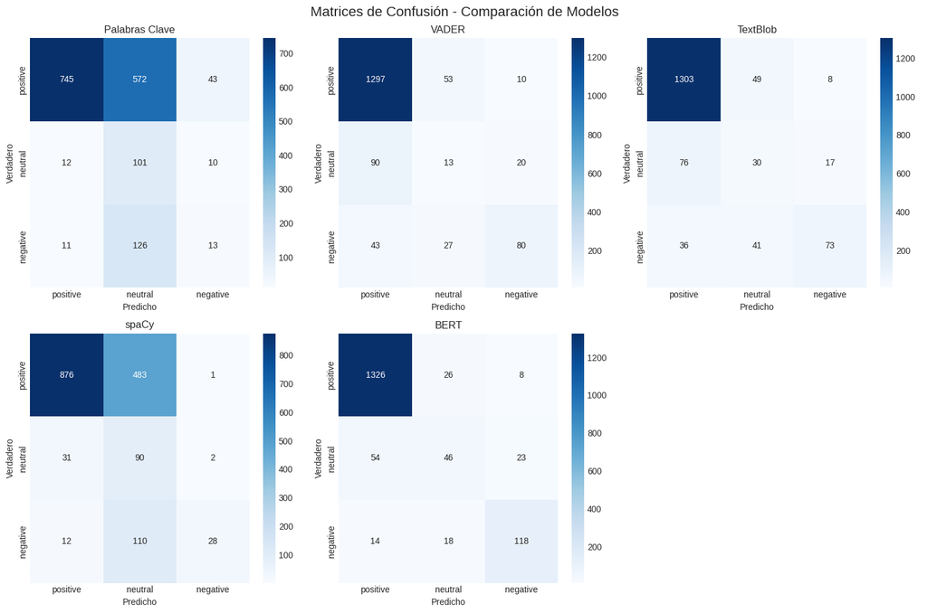

```
 Matrices de confusión generadas
```

```python
# Crear matrices de confusión para cada modelo
fig, axes = plt.subplots(2, 3, figsize=(15, 10))
fig.suptitle('Matrices de Confusión - Comparación de Modelos', fontsize=16)

models = []

# Add Keyword sentiment
if 'keyword_sentiment' in df.columns:
    models.append(('Palabras Clave', df['keyword_sentiment'], df['true_sentiment']))

# Add VADER sentiment
if 'vader_sentiment' in df.columns:
    models.append(('VADER', df['vader_sentiment'], df['true_sentiment']))

# Add TextBlob sentiment
if 'textblob_sentiment' in df.columns:
    models.append(('TextBlob', df['textblob_sentiment'], df['true_sentiment']))

# Add spaCy sentiment
if 'sentiment_spacy' in df.columns:
    models.append(('spaCy', df['sentiment_spacy'], df['true_sentiment']))

# Add BERT sentiment
if 'sentiment_bert' in df.columns and BERT_AVAILABLE:
    models.append(('BERT', df['sentiment_bert'], df['true_sentiment']))

# Llenar con gráfico vacío si no hay suficientes modelos (máx 6 plots)
while len(models) < 6:
    models.append(('', None, None))

labels = ['positive', 'neutral', 'negative']

for idx, (model_name, y_pred, y_true) in enumerate(models):
    ax = axes[idx // 3, idx % 3]

    if y_pred is not None and y_true is not None:
        # Filtrar NaN
        mask = ~(pd.isna(y_true) | pd.isna(y_pred))
        y_true_clean = y_true[mask]
        y_pred_clean = y_pred[mask]

        cm = confusion_matrix(y_true_clean, y_pred_clean, labels=labels)

        # Visualizar
        sns.heatmap(cm, annot=True, fmt='d', cmap='Blues',
                   xticklabels=labels, yticklabels=labels, ax=ax)
        ax.set_title(f'{model_name}')
        ax.set_ylabel('Verdadero')
        ax.set_xlabel('Predicho')
    else:
        ax.axis('off') # Turn off axis for empty plots

plt.tight_layout()
plt.show()

print(" Matrices de confusión generadas")
```

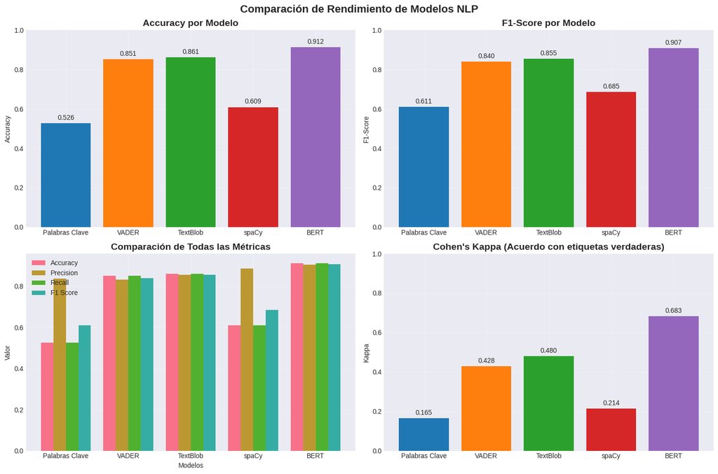

```python
# Visualización comparativa de métricas
fig, axes = plt.subplots(2, 2, figsize=(15, 10))

# 1. Comparación de Accuracy
ax = axes[0, 0]
models_names = metrics_df['model'].tolist()
accuracies = metrics_df['accuracy'].tolist()
bars = ax.bar(models_names, accuracies, color=['#1f77b4', '#ff7f0e', '#2ca02c', '#d62728', '#9467bd'])
ax.set_title('Accuracy por Modelo', fontsize=14, fontweight='bold')
ax.set_ylabel('Accuracy')
ax.set_ylim([0, 1])
ax.grid(True, alpha=0.3)

# Añadir valores en las barras
for bar, val in zip(bars, accuracies):
    height = bar.get_height()
    ax.text(bar.get_x() + bar.get_width()/2., height + 0.01,
            f'{val:.3f}', ha='center', va='bottom')

# 2. Comparación de F1-Score
ax = axes[0, 1]
f1_scores = metrics_df['f1_score'].tolist()
bars = ax.bar(models_names, f1_scores, color=['#1f77b4', '#ff7f0e', '#2ca02c', '#d62728', '#9467bd'])
ax.set_title('F1-Score por Modelo', fontsize=14, fontweight='bold')
ax.set_ylabel('F1-Score')
ax.set_ylim([0, 1])
ax.grid(True, alpha=0.3)

for bar, val in zip(bars, f1_scores):
    height = bar.get_height()
    ax.text(bar.get_x() + bar.get_width()/2., height + 0.01,
            f'{val:.3f}', ha='center', va='bottom')

# 3. Comparación de métricas múltiples
ax = axes[1, 0]
metrics_to_compare = ['accuracy', 'precision', 'recall', 'f1_score']
x = np.arange(len(models_names))
width = 0.2

for i, metric in enumerate(metrics_to_compare):
    values = metrics_df[metric].tolist()
    ax.bar(x + i*width, values, width, label=metric.replace('_', ' ').title())

ax.set_xlabel('Modelos')
ax.set_ylabel('Valor')
ax.set_title('Comparación de Todas las Métricas', fontsize=14, fontweight='bold')
ax.set_xticks(x + width * 1.5)
ax.set_xticklabels(models_names)
ax.legend()
ax.grid(True, alpha=0.3)

# 4. Cohen's Kappa (medida de acuerdo)
ax = axes[1, 1]
kappa_scores = metrics_df['kappa'].tolist()
bars = ax.bar(models_names, kappa_scores, color=['#1f77b4', '#ff7f0e', '#2ca02c', '#d62728', '#9467bd'])
ax.set_title("Cohen's Kappa (Acuerdo con etiquetas verdaderas)", fontsize=14, fontweight='bold')
ax.set_ylabel('Kappa')
ax.set_ylim([0, 1])
ax.grid(True, alpha=0.3)

for bar, val in zip(bars, kappa_scores):
    height = bar.get_height()
    ax.text(bar.get_x() + bar.get_width()/2., height + 0.01,
            f'{val:.3f}', ha='center', va='bottom')

plt.suptitle('Comparación de Rendimiento de Modelos NLP', fontsize=16, fontweight='bold')
plt.tight_layout()
plt.show()
```